# AH-LING203 Corpus Linguistics Spring 2023

2023-02-06

# Introduction

R is a programming language created for statistical computing and data visualization. To work with R, we tend to use a environment called RStudio. If you have not installed RStudio yet, follow the instructions that you can find on the [data center website](https://ucrdatacenter.github.io/tutorial/r_install.html). It is important to work in projects to keep your work organized. Create a new project and open a new R Script in there to run the examples from this workshop. If you need help creating a project, you can find some extra info [here](https://ucrdatacenter.github.io/tutorial/r_basics.html). First we’ll go through some of the basics of R, before we start making our frequency plot. If you would like some extra information, you can always find some nice tutorials [here](https://ucrdatacenter.github.io/tutorial/r_basics.html#Supporting_materials). We highly recommend you read through sections 2, 3.1-3.4 and 4-6 of A (very) short introduction to R and sections 1-4 of How to make any plot in ggplot2? before starting with R. Don’t worry if you don’t understand anything right away. Most things will become clear when you start working on it.

Everything that is not a comment will be seen as executable code. If we place a single hashtag before anything, it will turn green and become a comment. You can run a piece of code by selecting it and pressing Control+Enter for Windows or Command+Enter for Mac.

# Workshop 1: Simple Frequency Plot

## Packages

Open a new notebook inside your project. Right now, you don’t have any loaded packages in your script. This means that all the functions and data frames you can use are restricted to base R. However, base R is pretty limited. So you definitely need some help.

Packages in R consist of functions, compiled code, and sample data. These packages are stored under a directory called a “library” within the R environment. Before you can use a package, you must first install it. You can do this by running the following code or by going to Tools > Install Packages. For this assignment, you will need tidyverse and tidytext.

```r
install.packages("tidyverse")
install.packages("tidytext")
```

Now that you have installed the packages, you must first load them in by running the following code for every package that you would like to use.

```r
library(tidyverse)
library(tidytext)
```

If you want to learn more about a package or read up on a specific function, you can use “?” followed by the function, package, or dataset. Read a little bit about the tidyverse package and the read_csv function. What does the read_csv function do? What do some of the arguments do?

```r
?tidyverse
?read_csv
```

Let’s now load a data frame into your R Environment. You can do this by using the assignment operator <- (Alt - for Windows and Option - for Mac). Variables can be anything from characters, to numbers, to whole data frames. Always choose an appropriate name for the variables you are creating. Try to avoid obscure names like x or y, and use descriptive names like word_list or wikipedia_texts. Using descriptive names will make it a lot easier to follow the code for yourself and for others to understand what you are doing.

## DATA

In this assignment, you will have to use the “musicians.csv” file. You can download that [here](https://raw.githubusercontent.com/ucrdatacenter/projects/main/AHLING203/2023h1/musicians.csv).

The data frame consists of an musicians’s name and all the text from their Wikipedia page. This is done with webscraping, a skill you will get introduced to in the second workshop. For now we will create a simple frequency plot. Make sure that this file is placed inside your current working directory, which you can find by running the following command.

```r
getwd()
```

The following code will load the data frame “musicisians.csv” and assign the name wikipedia_texts to it. It uses the function read_delim to load it in.

```r
wikipedia_texts <- read_delim("musicians.csv", delim = ";")
```

As you can see, a new variable with your data frame has been added to your Environment section (top right) in RStudio. To view your data frame you can open it by double clicking it there or you can use the view() function.

```r
view(wikipedia_texts)
```

As you can see, it does not look pretty right now, because the data frame only consists of five artist names and then a large string object. (A string variable has values that are treated like text.) Since we want to see each word individually we’ll use the function; unnest_tokens. Find out what this function does with “?”

```r
?unnest_tokens
```

We are now making a new object “wikipedia_words” that splits the paragraphs under entry_text from “wikipedia_texts” into separate words and we are calling that column “word”.

```r
wikipedia_words <- unnest_tokens(wikipedia_texts, word, entry_text)
```

Let’s examine the new data frame we created. What do these functions do?

```r
head(wikipedia_words)
tail(wikipedia_words)
```

Now let’s count how often each word occurs. Again we are making a new object called “word_freq” by using the <- operator. The “%>%” thing is called the pipe operator. It is used to perform some function on an object and then passing the result through the next function, creating a “pipeline”. The count function is used here to count each word per artist (“Name”) and to sort the outcome.

```r
word_freq <- wikipedia_words %>%
  count(Name, word, sort= T)
```

Take a look:

```r
head(word_freq)
```

As you can see, the words that occur the most often are not very informative. Luckily, the tidytext package has a build in data frame that contains English stop words from three lexicons.

```r
?stop_words
head(stop_words)
```

Since we do not want to include these stop words in our final visualization, we have to filter them out. To do this, we use the filter() function. Try to figure out in one sentence what the following code does.

```r
word_freq <- filter(word_freq, !word %in% stop_words$word)
```

Take a look at how the data frame changed.

```r
head(word_freq)
```

The data frame still contains some numbers such as years and other numbers. Depending on your research, you have to decide whether or not you would like to include these (just like with the stop words). For this project we want to filter those out as well. Again we use the “!” and now also use the function str_detect() function.

str_detect() can be used to detect the presence (or absence) of a pattern in a string. In this case we are filtering out any string that has a number from 0 to 9 in it

```r
words_final <- filter(word_freq, !str_detect(word, "[0-9]"))
```

## Visualization

Finally we have come to the fun part: data visualization!

The first visualization will contain the top 20 most frequently used words from the wikipedia page of Miles Davis. Again we use the filter function for this, to extract the Miles Davis text. We then apply the top_n() function to get the top 20 most frequently used words.

```r
Miles_20 <- words_final %>%
  filter(Name == "Miles_Davis") %>%
  top_n(20)
```

Now, let’s make a graph displaying the top 20 most used words. To make a plot we use ggplot. Use ? to find out more about ggplot!

(aes(word, n)) constructs aesthetic mappings taking the column “word” as the x axis and the number of times the word occurs “n” as the y axis. We then add a bar graph by using + geom_col(). xlab(NULL) means that the x axis label will take no value, it will be empty. coord_flip, flips the whole graph 90 degrees so it’s easier to read (note that n which is the count is now on the x axis).

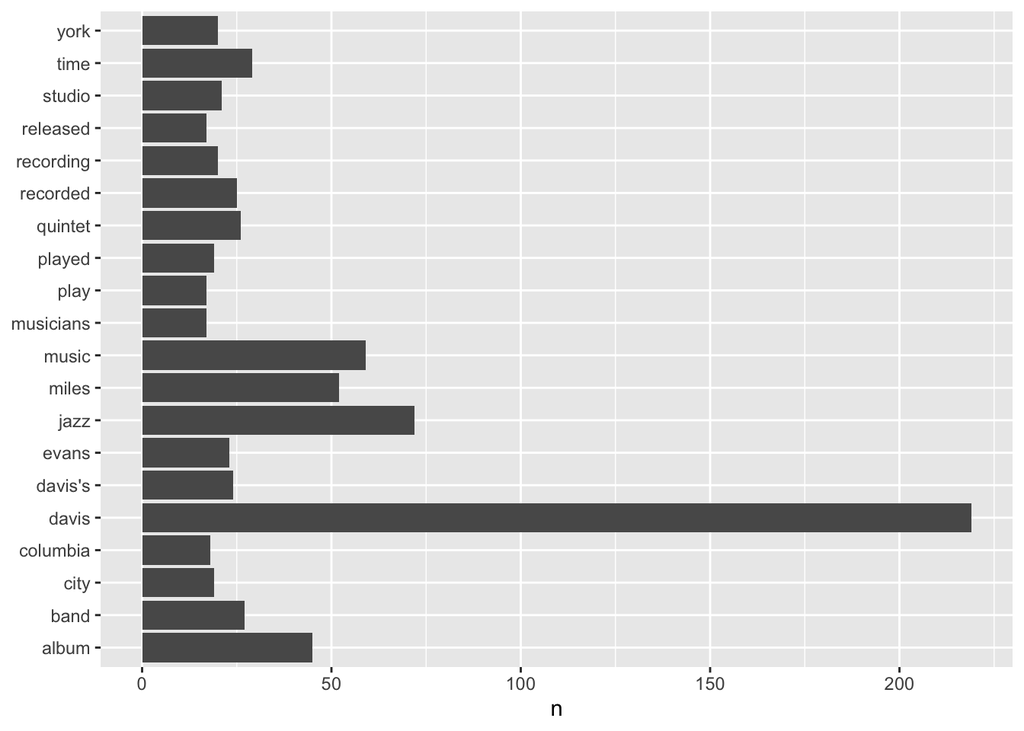

```r
Miles_20 %>%
  ggplot(aes(word, n)) +
  geom_col() + xlab(NULL) + coord_flip()
```

As you can see the words “davis” and “miles” are part of the top 20. Can you figure out what the code below does?

```r
Miles_20 <- words_final %>%
  filter(Name == "Miles_Davis") %>%
  filter(!word %in% c("davis", "miles")) %>%
  top_n(20)
```

To make the graph more appealing, we will be ordering the words from biggest count to lowest. We do this using the mutate() function. Use ? to figure out what this function does. We then create a new plot. What has changed?

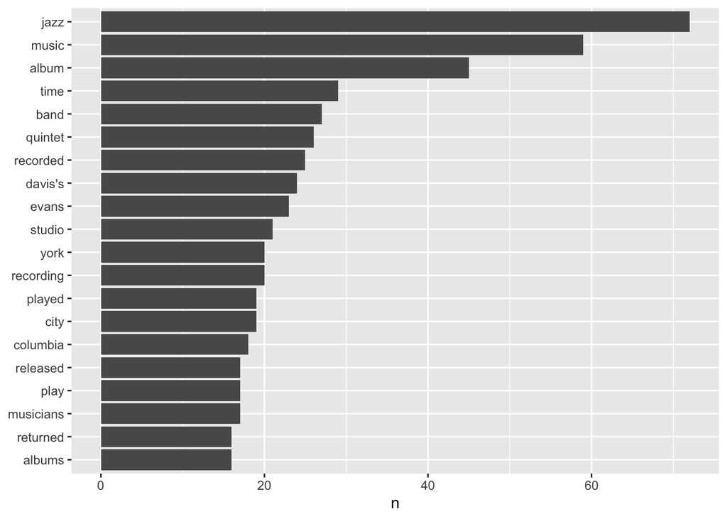

```r
Miles_20 %>%
  mutate(word = reorder(word, n)) %>%
  ggplot(aes(word, n)) + geom_col() + xlab(NULL) + coord_flip()
```

Before you go to work on the assignment, try to create a similar plot with one of the other musicians in the file. See if you can get rid of the stop words and, if you have time left, try to customize the plot with some additional ggplot functions. You can find resources on how to work with ggplot on the [data center website](https://ucrdatacenter.github.io/tutorial/r_basics.html#Help_with_ggplot). As always, you can also use the ? operator to learn more about the functions. See if you can change the theme, colors, or fonts. Perhaps you want to add a title or use the WesAnderson package to use a color palette from one of his movies!

## Extra: Wordcloud

For our second data visualization we want to make a wordcloud. Even though it’s not very informative, it does look quite nice. Load the package “wordcloud” and install it first if needed. If you are up for a challenge, see if you can create one from scratch! Otherwise, you can just copy the code below and have some fun with changing the parameters. Maybe you can create a pretty wordcloud for one of the other musicians!

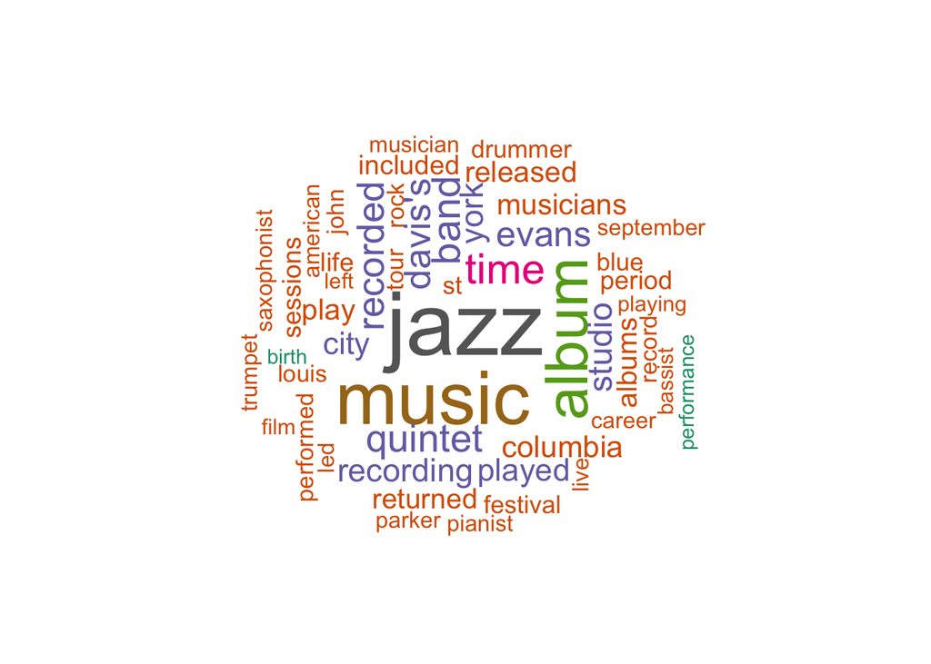

```r
library(wordcloud)
words_final %>%
  filter(Name == "Miles_Davis") %>%
  filter(!word %in% c("davis", "miles")) %>%
  with(wordcloud(word, n, max.words = 50, random.order = FALSE, rot.per = 0.35,
                             colors = brewer.pal(8, "Dark2")))
```

# Workshop 2: Webscraping